# Plantilla de comparacions

VHIR-UEB-for-019v.01

# 1 Introducció

Aquesta plantilla mostra un exemple d’anàlisi comparativa, metodologia que compara dues o més variables, que poden ser quantitatives (numèriques) o qualitatives (caràcters o factors), per a entendre millor les seves característiques i relacions.

Per identificar si hi ha diferències o tendències entre els elements comparats, s’aplica una tècnica de comparació de dades basada en hipòtesis o suposicions que es formen a partir de l’anàlisi exploratòria.

Podem definir una **hipòtesi** com una resposta a una pregunta que es fa l’investigador que encara no s’ha testat, com ara: existeixen diferències entre dues mitjanes o entre dues proporcions?

Els **tests d’hipòtesis** poden ser paramètrics (que assumeixen certes distribucions) o no paramètrics (que no fan suposicions sobre la distribució de les dades). Aquests tests es basen en un contrast de dues hipòtesis que poden ser considerades contràries: la **hipòtesi nul·la** ($H_0$), que generalment és una afirmació del fet que no hi ha una situació d’interès, per exemple: la diferència de dues mitjanes és igual a 0 i la **hipòtesi alternativa** ($H_1$), que normalment representa l’afirmació que l’investigador vol provar, per exemple: la diferència de dues mitjanes és diferent de 0. Quan volem determinar si una és major o menor que l’altre, denominem la alternativa com unilateral, i quan volem investigar si hi ha una diferència, l’anomenem bilateral.

Per avaluar l’evidència en contra de la hipòtesi nul·la, s’utilitza un **estadístic de contrast**, que és una estimació puntual o un estadístic mostral. La fórmula d’aquesta mesura depèn del tipus de contrast i quantifica la desviació dels resultats observats dels esperats sota la hipòtesi nul·la.

El **valor p** és la probabilitat d’obtenir un estadístic de contrast igual o més extrem que l’estadístic de contrast observat suposant que la hipòtesi nul·la és certa, on l’estadístic de contrast observat és el valor de l’estadístic de contrast que observem a la mostra, com per exemple: la diferència entre dues mitjanes.

El **nivell de significació**, representat per $\alpha$ (alpha), és la probabilitat de rebutjar incorrectament la hipòtesi nul·la quan aquesta és certa, és a dir, el risc de concloure erròniament l’existència d’una diferència quan no n’hi ha. Els valors més comuns son 1%, 5% i 10%. El **valor crític** és un valor límit que depèn de la distribució de l’estadístic de contrast i serveix per a separar la zona de rebuig de la de no rebuig.

Si l’estadístic de contrast es troba dins la regió de rebuig o el valor p és inferior al nivell de significació (habitualment 0.05), aleshores es considera que tenim evidències suficients per a rebutjar la hipòtesi nul·la en favor de la alternativa. En canvi, si l’estadístic de contrast se situa dins la regió de no rebuig o el valor p és igual o superior al nivell de significació, concloem que no disposem de prou evidències per a rebutjar la hipòtesi nul·la, que no és el mateix que dir que acceptem la hipòtesi nul·la.

Abans de començar amb aquesta anàlisi en programari R, es recomana consultar la plantilla de descriptius on estan explicats els passos previs de qualsevol anàlisi. A continuació, ja es pot procedir a l’anàlisi comparativa.

En aquest exemple utilitzarem la base de dades **diabetes**.

Tots els análisis han estat realitzats emb el programa estadístic “R”( R version 4.4.0 (2024-04-24 ucrt), Copyright (C) 2015 The R Foundation for Statistical Computing ).

# 2 Análisis comparatiu

```r
> ##################
> #### GRUPS DE VARIABLES
> ##################
>
> var_names <- names(dat) # nom de totes les variables
> var_group <- c("mort", "tabac") # variables grup
> var_select <- c("tempsviu","edat","ecg","chd") # variables seleccionades
> var_id <- "id" # Identificador del subjecte
>
> ##################
```

Per a comparar les diferents categories de les variables d’interès: mort, tabac s’ha realitzat un test de comparació entre grups amb la funció `desc_group()` del paquet *anaStatsUEB*. Aquesta funció, com es pot veure a la plantilla de descriptius, retorna una taula descriptiva llesta per a ser visualitzada en html. A més, depenent del tipus d’estudi, de variables, del nombre de grups a comparar i de com se seleccionen els grups, la funció retorna un valor p per a cadascun dels contrastos de variables obtingut a partir de diferents tests.

- En el cas que la variable fila sigui **quantitativa**, s’ha realitzat:
  - TEST PARAMÈTRIC:
    - Per a **2 grups independents**: una prova *t de Student*.

      La prova comprova si les mitjanes dels dos grups independents són iguals. Ex: comparar les mitjanes de l’IMC entre homes i dones.

      Contrast:
      $$\left\{ \begin{array}{ll} H_{0}: & \mu_1 = \mu_2 \\ H_{1}: & \mu_1 \neq \mu_2 \end{array} \right. \space o \space \left\{ \begin{array}{ll} H_0: & \mu_1 - \mu_2 = 0 \\ H_1: & \mu_1 -\mu_2 \neq 0 \end{array} \right.$$

      Per a obtenir el valor p hem de calcular l’estadístic t:

      $$t = \frac{(\bar{x}_{1} - \bar{x}_2)}{s_{\bar{x}_1 - \bar{x}_2}}$$
      On:

      – $\bar{x}_{1}$ i $\bar{x}_2$ són les mitjanes mostrals

      – $s_{\bar{x}_1 - \bar{x}_2} = s \sqrt{\frac{1}{n_1} + \frac{1}{n_2}}$ és l’error estàndard quan les variàncies poblacionals són iguals

      – $s = \sqrt{\frac{(n_1 -1)s_1^2 + (n_2 -1)s_2^2}{gl}}$ és la desviació típica

      – $n_1$ i $n_2$ són les grandàries mostrals

      – $s_1^2$ i $s_1^2$ són les variàncies mostrals

      – $gl = n_1 + n_2 -2$ són els graus de llibertat
    - Per a **>2 grups independents**: una *ANOVA (anàlisi de la variància)*.

      La prova comprova si les mitjanes poblacionals de tres o més grups independents són iguals analitzant la variabilitat entre les mitjanes de les mostres. Ex: comparar les mitjanes de les puntuacions de 3 qüestionaris.

      Contrast:
      $$\left\{
      \begin{array}{ll}
      H_{0}: & \mu_1 = \mu_2 = ... = \mu_k \\
      H_{1}: & \exists\mu_i \neq \mu & i = 1,2,...,k
      \end{array}
      \right.$$

      Per a obtenir el valor p hem de calcular l’estadístic F:

      $$F = \frac{MSE_F}{MSE_E}$$
      On:

      – $F$ (factor) indica entre grups, $E$ (error) indica dins dels grups i $T$ total

      – $MSE$ indica error quadràtic mitjà, $SS$ indica suma de quadrats i $gl$ indica graus de llibertat

      – $MSE_F = \frac{SS_F}{gl_F}$ , $SS_F = \sum_{i=1}^k{n_i \cdot(\bar{x}_i-\bar{x})^2}$ , $gl_F = k-1$

      – $MSE_E = \frac{SS_E}{gl_E}$ , $SS_E = \sum_{i=1}^{k}\sum_{j=1}^{n_i}{({x}_{ij}-\bar{x}_i)^2}$ , $gl_E = N - k$

      – $SS_T = \sum_{i=1}^{k}\sum_{j=1}^{n_i}{({x}_{ij}-\bar{x})^2}$ , $gl_T = N-1$

      – $N = n_1 + n_2 + ... + n_k$ és el número total d’observacions

      – $n_k$ són les grandàries mostrals

      – $k$ és el número de grups

      – $x_{ij}$ és el valor $j$ del grup $i$

      – $\bar{x}_{i}$ és la mitjana del grup $i$

      – $\bar{x}$ és la mitjana de totes les dades
      - Per a **2 grups aparellats**: un test *t aparellat*.

        La prova comprova si les mitjanes dels dos grups dependents (un valor d’un grup està relacionat amb un de l’altre grup) distribuïts de forma normal són iguals. Ex: comparar mitjanes d’una anàlisi amb valors pre i post.

        Contrast:
        $$\left\{
        \begin{array}{ll}
        H_{0}: & \mu_1 = \mu_2 \\
        H_{1}: & \mu_1 \neq \mu_2
        \end{array}
        \right.
        \space
        o
        \space
        \left\{
        \begin{array}{ll}
        H_0: & \mu_1 - \mu_2 = 0 \\
        H_1: & \mu_1 -\mu_2 \neq 0
        \end{array}
        \right.$$

        Per a obtenir el valor p hem de calcular l’estadístic t:

        $$t = \frac{\overline{diff}}{s_d / \sqrt{n}}$$
        On:

        – $diff = x_1 - x_2$ és la nova mostra, per tant, $\overline{diff}$ és la mitjana de la mostra

        – $s_d$ és la desviació típica mostral

        – $n$ és la mida de la mostra

        – $s_d^2$ és la variància mostral

        – $n-1$ són els graus de llibertat
  - TEST NO PARAMÈTRIC:
    - Per a **2 grups independents**: una prova *U de Mann Whitney*.

      La prova comprova si les distribucions o percentils dels dos grups independents són iguals. Ex: comparar les de l’IMC entre homes i dones.

      Contrast:
      $$\left\{ \begin{array}{ll} H_{0}: & P(X>Y) = P(Y>X) \\ H_{1}: & P(X>Y) \neq P(Y>X) \end{array} \right.$$

      Per a obtenir el valor p hem de calcular l’estadístic U:

      $$U = \min(U_1,U_2)$$
      On:

      – $U_1 = n_1n_2 + \frac{n_1(n_1+1)}{2}-R_1$ és l’estadístic per al grup 1

      – $U_2 = n_1n_2 + \frac{n_2(n_2+1)}{2}-R_2$ és l’estadístic per al grup 2

      – $n_1$ i $n_2$ són les grandàries mostrals

      – $R_1$ i $R_2$ són les sumes dels rangs (la suma de les posicions relatives de cada individu de la mostra)
    - Per a **>2 grups independents**: una prova *Kruskall-Wallis*.

      La prova comprova si les distribucions o percentils de tres o més grups independents són iguals. Ex: comparar IMC entre 3 grups d’edat.

      Contrast:
      $$\left\{ \begin{array}{ll} H_{0}: & P(X>Y) = P(Y>X) \\ H_{1}: & P(X>Y) \neq P(Y>X) \end{array} \right.$$

      Per a obtenir el valor p hem de calcular l’estadístic K :

      $$K = \frac{N-1}{N}\cdot\sum_{i=1}^k{\frac{n_i\cdot(\bar{R_i}-E_R)^2}{\sigma^2}}$$
      On:

      – $\sigma^2 = \frac{n^2 -1}{12}$ és la variància dels rangs

      – $E_R = \frac{n+1}{2}$ és el valor esperat dels rangs

      – $N$ és la grandària mostral total

      – $n_i$ és el nombre d’observacions en el grup $i$

      – $\bar{R_i} =\frac{\sum_{j=1}^{n_i}r_{ij}}{n_i}$ és la mitjana de les sumes dels rangs (la suma de les posicions relatives de cada individu de la mostra)

      – $r_{ij}$ és el rang de l’observació $j$ en el grup $i$
    - Per a **2 grups aparellats**: una prova dels *signes de Wilcoxon*.

      La prova comprova si les distribucions dels dos grups dependents són iguals. Ex: comparar valors Pre i Post.

      Contrast:
      $$\left\{ \begin{array}{ll} H_{0}: & P(X>Y) = P(Y>X) \\ H_{1}: & P(X>Y) \neq P(Y>X) \end{array} \right.$$

      Per a obtenir el valor p hem de calcular l’estadístic W:

      $$W = \min(W^+,W^-)$$

      On:

      – $W^+$ suma dels rangs amb signe positiu i $W^-$ suma dels rangs amb signe negatiu
- En el cas que la variable fila sigui **qualitativa**, s’ha realitzat:
  - TEST PARAMÈTRIC:
    - Per a **2 grups independents**: un test *z de comparació de proporcions*.

      La prova comprova si les proporcions dels dos grups independents són iguals mitjançant una taula de contingència.

      Contrast:
      $$\left\{
      \begin{array}{ll}
      H_{0}: & \pi_1 = \pi_2 \\
      H_{1}: & \pi_1 \neq \pi_2
      \end{array}
      \right.
      \space
      o
      \space
      \left\{
      \begin{array}{ll}
      H_0: & \pi_1 - \pi_2 = 0 \\
      H_1: & \pi_1 -\pi_2 \neq 0
      \end{array}
      \right.$$

      Per a obtenir el valor p hem de calcular l’estadístic Z:

      $$Z = \frac{(p_1-p_2)}{s}$$
      On:

      – $p_1$ i $p_2$ són les proporcions de les mostres

      – $s = \sqrt{p(1-p)(\frac{1}{n_1}+\frac{1}{n_2})}$ és l’error estàndard de la diferència

      – $p = \frac{x_1 +x_2}{n_1+n_2}$ és la proporció combinada de les mostres

      – $x_1$ i $x_2$ són el número d’encerts de les mostres

      – $n_1$ i $n_2$ són les grandàries mostrals
  - TEST NO PARAMÈTRIC:
    - Per a **2 grups independents**: una prova *chi-quadrat* o la prova *exacta de Fisher* quan les freqüències esperades són inferiors a 5 en algun cas.

      La prova $\chi^2$ comprova si hi ha associació entre els dos grups independents mitjançant una taula de contingència.

      Contrast:
      $$\left\{
      \begin{array}{ll}
      H_{0}: & independència \\
      H_{1}: & no \space independència
      \end{array}
      \right.$$

      Per a obtenir el p valor hem de calcular l’estadístic $\chi^2$:

      $$\chi^2 = \sum_{k=1}^n\frac{{(O_k-E_k)^2}}{E_k}$$
      On:

      – $O_k$ és el valor observat

      – $E_k = \frac{(suma \space fila\space \times \space suma \space columna)}{num \space total \space observacions}$ és el valor esperat

      – $df = (p-1)(q-1)$ són els graus de llibertat

      – $p$ i $q$ són els números de files i columnes

      – $x_1$ i $x_2$ són el número d’encerts de les mostres

      – $n_1$ i $n_2$ són les grandàries mostrals

      La prova exacta de Fisher comprova si hi ha associació entre els dos grups independents quan les freqüències esperades són inferiors a 5 en algun cas mitjançant una taula de contingència.

      Contrast:
      $$\left\{
      \begin{array}{ll}
      H_{0}: & independència \\
      H_{1}: & no \space independència
      \end{array}
      \right.$$

      Per a obtenir el p valor:
      $$p = \frac{(a+b)!\cdot(c+d)!\cdot(a+c)!\cdot(b+d)!}{a!\cdot b!\cdot c!\cdot d!\cdot n!}$$
      On:

      |  | **Grup1** | **Grup2** | Total de files |
      | --- | --- | --- | --- |
      | **Categoria 1** | a | b | a+b |
      | **Categoria 2** | c | d | c+d |
      | Total de columnes | a+b | b+d | a+b+c+d(=n) |

    - Per a **>2 grups independents**: una prova *chi-quadrat* quan menys del 20% de les freqüències són inferiors a 5 i el valor esperat és major a 1.

      La prova comprova si hi ha associació entre els dos grups independents mitjançant una taula de contingència.

      Contrast:
      $$\left\{
      \begin{array}{ll}
      H_{0}: & independència \\
      H_{1}: & no \space independència
      \end{array}
      \right.$$

      Per a obtenir el valor p hem de calcular l’estadístic $\chi^2$:
      $$\chi^2 = \sum_{k=1}^n\frac{{(O_k-E_k)^2}}{E_k}$$

      On:

      – $O_k$ és el valor observat

      – $E_k = \frac{(suma \space fila\space \times \space suma \space columna)}{num \space total \space observacions}$ és el valor esperat

      – $df = (p-1)(q-1)$ són els graus de llibertat

      – $p$ i $q$ són els números de files i columnes

      – $x_1$ i $x_2$ són el número d’encerts de les mostres

      – $n_1$ i $n_2$ són les grandàries mostrals
    - Per a **2 grups aparellats**: un test *Mcnemar*.

      La prova comprova si hi ha un canvi entre les proporcions dels dos grups dependents mitjançant una taula de contingència.

      Contrast:
      $$\left\{
      \begin{array}{ll}
      H_{0}: & p_b = p_c \\
      H_{1}: & p_b \neq p_c
      \end{array}
      \right.$$

      Per a obtenir el valor p hem de calcular l’estadístic $M$:
      $$M = \frac{(b-c)^2}{b+c}$$
      On:

      |  | **Grup 1** | **Grup 2** | Total de files |
      | --- | --- | --- | --- |
      | **Categoria 1** | a | b | a+b |
      | **Categoria 2** | c | d | c+d |
      | Total de columnes | a+b | b+d | a+b+c+d(=n) |

La funció per defecte utilitza els tests no paramètrics (que suposen que les dades no es distribueixen normalment), si volem utilitzar els paramètrics (que suposen normalitat), hem de posar `method = 'param'`. La funció també utilitza per defecte dades independents, si volem utilitzar dades aparellades hem de posar `paired = TRUE`.

Per a tots aquells contrastos amb un **p-valor no ajustat inferior a 0.05**, es mostra una anàlisi gràfica de la parella de variables.

- Per a les variables **categòriques** s’ha realitzat un *diagrama de barres*, on cada barra indica un grup i cada color una categoria de la variable clínica a tenir en compte, l’eix vertical indica el percentatge.
- Per a les variables **numèriques** s’ha realitzat un *boxplot* (diagrama de caixes) tenint en compte cadascun dels grups.

```r
> res2 <- list() # creem una llista buida per guardar els resultats
>
> # bucle d'anàlisi per a cadascuna de les variables grup
> for(i in seq_along(var_group)){
+   cat("  \n##", var_group[i], " \n")
+
+   # taula de descriptius
+   res2[[i]] <- desc_group(covariates = var_select, group = var_group[i],
+                           data = dat,show.all = F)
+   print(res2[[i]]$res)
+
+   # si no hi ha cap contrast amb p-valor no ajustat inferior a 0.05 ens saltem
+   # l'anàlisi gràfica per a que no doni error
+
+   if(class(res2[[i]]$selVar) == "character"){
+     desc_plot(covariates = res2[[i]]$selVar,y = var_group[i],dat = dat, las = 2,
+               rowcol = c(1,1))
+     } else {
+       break
+     }
+   cat("\n")
+ }
```

## 2.1 mort

Table 2.1: Summary of results by groups of mort

| variable | levels | Vivo 124 (83.22%) | Muerto 25 (16.78%) | p.value | n |
| --- | --- | --- | --- | --- | --- |
| tempsviu<sub>2</sub> |  | 124 10.9 (4.1) CI[10.2; 11.6] 12.2 [9, 14.1] | 25 8.6 (3.9) CI[7; 10.2] 8 [5.5, 11] | 0.005 | 149 |
| edat<sub>2</sub> |  | 124 50.1 (10.6) CI[48.2; 52] 49 [42, 55.2] | 25 62.3 (12.4) CI[57.2; 67.4] 64 [52, 72] | <0.001 | 149 |
| ecg<sub>1</sub> | Normal | 97 (78.2%) CI[69.9; 85.1] | 14 (56%) CI[34.9; 75.6] | <0.001 | 149 |
|  | Anormal | 4 (3.2%) CI[0.9; 8.1] | 7 (28%) CI[12.1; 49.4] |  |  |
|  | Frontera | 23 (18.5%) CI[12.1; 26.5] | 4 (16%) CI[4.5; 36.1] |  |  |
| chd<sub>1</sub> | No | 86 (69.4%) CI[60.4; 77.3] | 13 (52%) CI[31.3; 72.2] | 0.149<sup>4</sup> | 149 |
|  | Si | 38 (30.6%) CI[22.7; 39.6] | 12 (48%) CI[27.8; 68.7] |  |  |

* 1: by col n(%) [Exact CI] p.value: <sup>3</sup>Fisher’s exact p.value: <sup>4</sup>Chi-squared  
† 2: N mean(sd) [CI95% mean] median[IQR] p.value: Mann–Whitney U

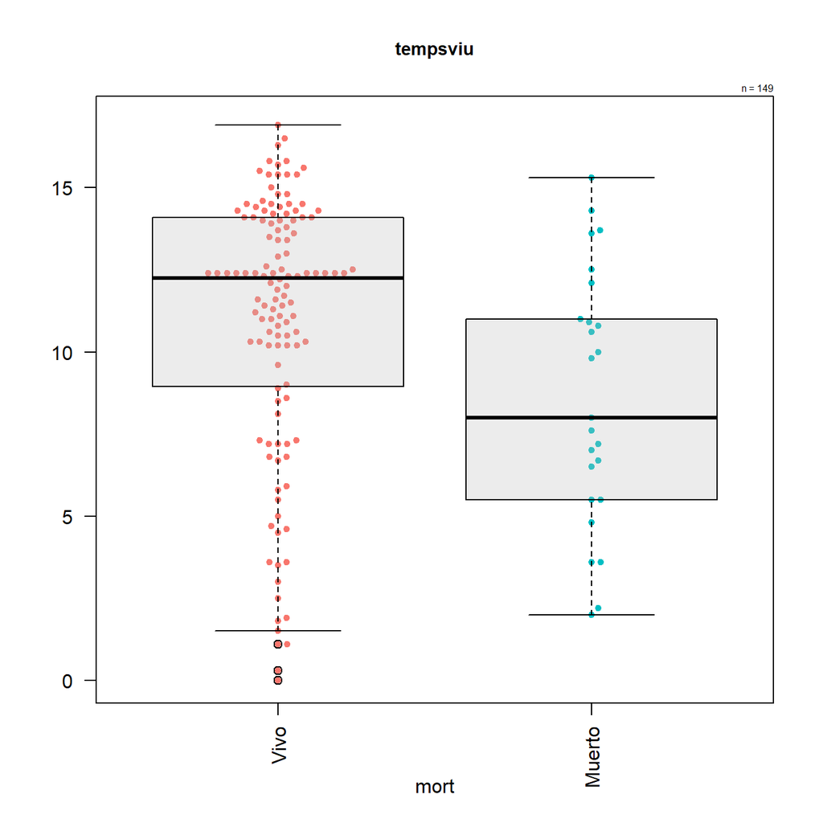

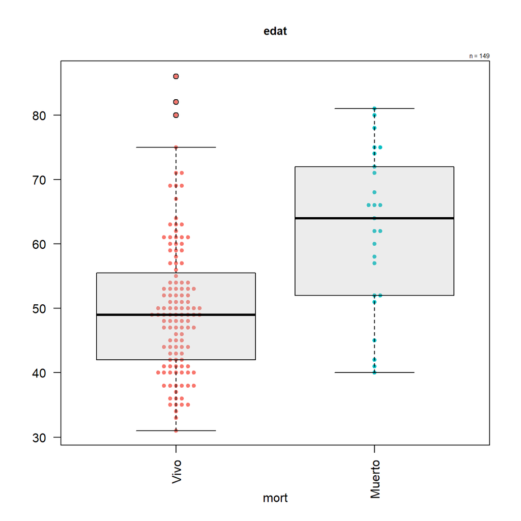

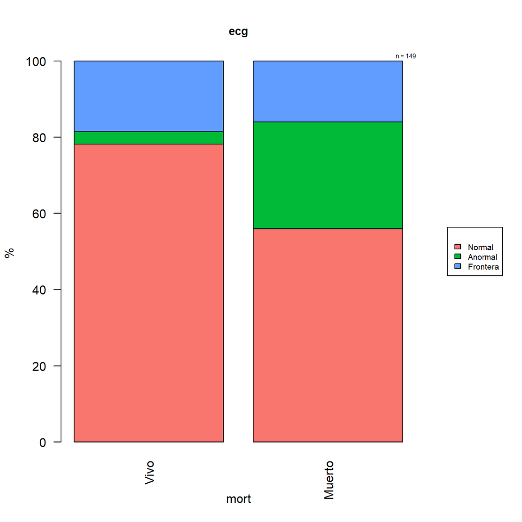

## 2.2 tabac

Table 2.1: Summary of results by groups of tabac

| variable | levels | No fumador 57 (38.26%) | Ex fumador 41 (27.52%) | Fumador 51 (34.23%) | p.value | n |
| --- | --- | --- | --- | --- | --- | --- |
| tempsviu<sub>2</sub> |  | 57 10.5 (4.2) CI[9.4; 11.7] 11.5 [7.3, 14] | 41 9.6 (4.2) CI[8.2; 10.9] 10.5 [5.9, 12.9] | 51 11.3 (3.8) CI[10.2; 12.3] 12.4 [10.2, 14.1] | 0.166 | 149 |
| edat<sub>2</sub> |  | 57 56.3 (11.9) CI[53.1; 59.4] 54 [47, 62] | 41 54.7 (12.3) CI[50.8; 58.6] 52 [48, 63] | 51 45.5 (7.7) CI[43.4; 47.7] 44 [40, 51] | <0.001 | 149 |
| ecg<sub>1</sub> | Normal | 41 (71.9%) CI[58.5; 83] | 28 (68.3%) CI[51.9; 81.9] | 42 (82.4%) CI[69.1; 91.6] | 0.558<sup>3</sup> | 149 |
|  | Anormal | 4 (7%) CI[1.9; 17] | 4 (9.8%) CI[2.7; 23.1] | 3 (5.9%) CI[1.2; 16.2] |  |  |
|  | Frontera | 12 (21.1%) CI[11.4; 33.9] | 9 (22%) CI[10.6; 37.6] | 6 (11.8%) CI[4.4; 23.9] |  |  |
| chd<sub>1</sub> | No | 38 (66.7%) CI[52.9; 78.6] | 23 (56.1%) CI[39.7; 71.5] | 38 (74.5%) CI[60.4; 85.7] | 0.177<sup>4</sup> | 149 |
|  | Si | 19 (33.3%) CI[21.4; 47.1] | 18 (43.9%) CI[28.5; 60.3] | 13 (25.5%) CI[14.3; 39.6] |  |  |

* 1: by col n(%) [Exact CI] p.value: <sup>3</sup>Fisher’s exact p.value: <sup>4</sup>Chi-squared  
† 2: N mean(sd) [CI95% mean] median[IQR] p.value: Kruska-Wallis

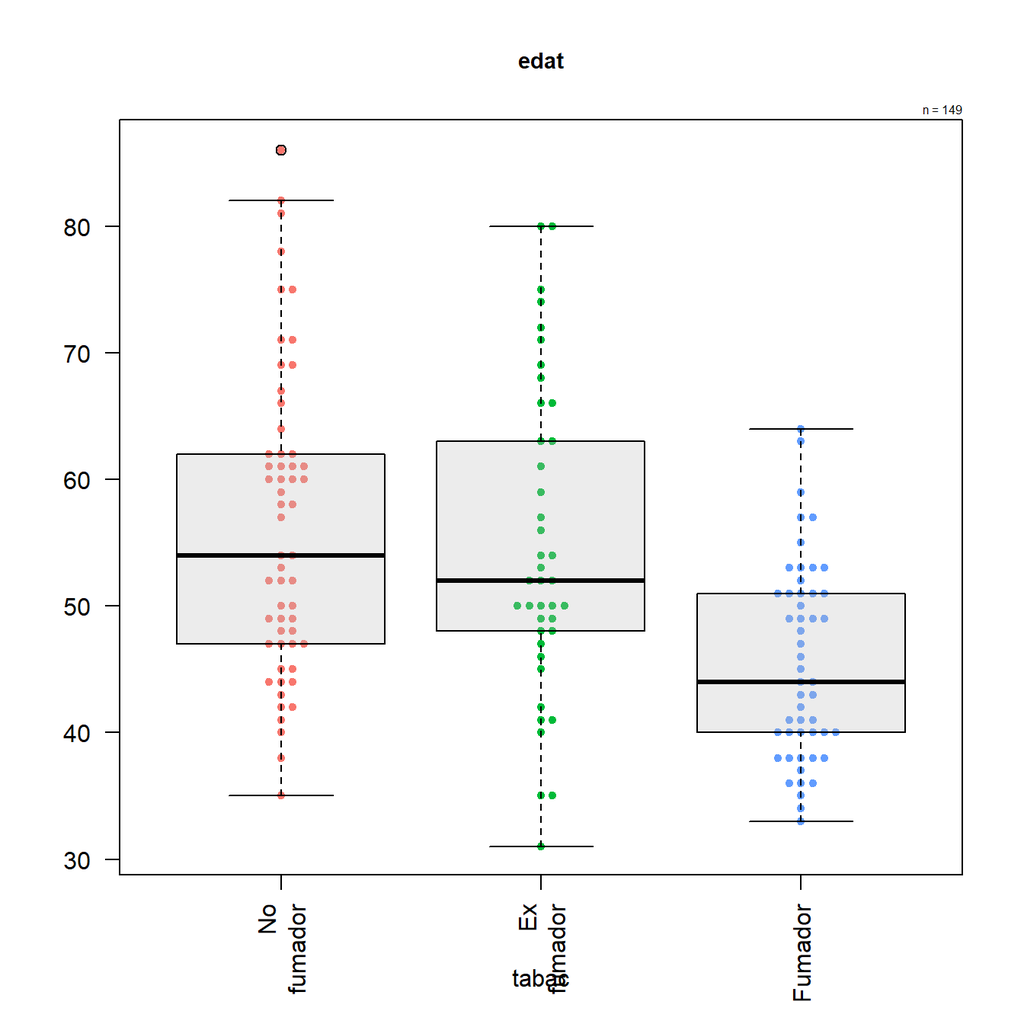

En aquest exemple veiem que els Vivo en mitjana han estat vius més temps que els Muerto, i aquesta diferència és significativa.

Pel que fa a l’edat, els Muerto tenen edats majors en mitjana que els Vivo, amb una diferència també significativa.

Si ens fixem en la variable ecg, el 78.2% dels Vivo tenen una ecg Normal, i els Muerto tenen un 56% de Normal i un 28% d’Anormal, aquesta diferència de percentatges ho considerem significativa.

En canvi, la diferència de percentatges entre Muerto i Vivo de la variable chd Si/No, no és tan gran, per tant, aquesta no es considera significativa.

En el cas dels grups de tabac, només és significativa la diferència d’edats, on els No fumador tenen en mitjana edats superiors, seguits dels Ex fumadors i per últim els fumadors.